# Lab 6: MIMO, Beamforming, and Diversity Combining

Name: Marc Pham

# Lab 6, Task 1A: MIMO Channel Estimation and Capacity

Estimate a 2 by 2 channel and compare equal-total-power MIMO and SISO capacity.

```python
from pathlib import Path
import sys
import numpy as np
from IPython.display import display, Image

def find_lab_root(start=Path.cwd()):
    for candidate in (start, *start.parents):
        if (candidate / "support" / "lab6_dsp.py").is_file():
            return candidate
    raise FileNotFoundError("Open this notebook from the Lab 6 folder tree")

LAB_ROOT = find_lab_root()
sys.path.insert(0, str(LAB_ROOT / "support"))
import lab6_dsp as lab
import lab6_tools as tools
print("Lab folder:", LAB_ROOT.name)
```

```
Lab folder: Lab6
```

## Simulation settings

Use the SNR values and number of channel realizations specified in the manual.

```python
snr_db = np.arange(0, 26, 5)
realizations = 5000
results = lab.simulate_mimo_capacity(snr_db, realizations=realizations, seed=7601)
print('SNR (dB):', results['snr_db'])
print('Mean 2x2 capacity:', np.round(results['mimo_capacity_bps_hz'], 3))
```

```
SNR (dB): [ 0.  5. 10. 15. 20. 25.]
Mean 2x2 capacity: [ 2.578  3.792  5.775  8.376 11.367 14.531]
```

## One least-squares calculation

For $Y=HX+N$, use $\hat H=YX^H(XX^H)^{-1}$. The array dimensions are receive branches by samples for `y`, and transmit branches by samples for `x`.

```python
rng = np.random.default_rng(6)
h_true = np.array([[0.8+0.2j, -0.3+0.5j], [0.4-0.1j, 0.7+0.3j]])
x = (rng.standard_normal((2, 2000)) + 1j*rng.standard_normal((2, 2000))) / np.sqrt(2)
y = h_true @ x

h_hat = (y @ x.conj().T) @ np.linalg.inv(x @ x.conj().T)
print('Estimated H:\n', np.round(h_hat, 4))
print('Maximum coefficient error:', np.max(np.abs(h_hat-h_true)))
```

```
Estimated H:
 [[ 0.8+0.2j -0.3+0.5j]
 [ 0.4-0.1j  0.7+0.3j]]
Maximum coefficient error: 2.2887833992611187e-16
```

## Capacity calculation

Use $C=\log_2\det(I_{N_r}+(\rho/N_t)HH^H)$. `rho` is linear total receive SNR.

```python
rho_db = 15.0

rho = 10**(rho_db / 10)
capacity = np.log2(np.linalg.det(np.eye(h_hat.shape[0]) + (rho / h_hat.shape[1]) * (h_hat @ h_hat.conj().T))).real
print(f'Capacity at {rho_db:.1f} dB: {capacity:.3f} bit/s/Hz')
```

```
Capacity at 15.0 dB: 6.856 bit/s/Hz
```

## Expected plot

The plotting code is supplied.

**Report:** Explain why MIMO capacity depends on both SNR and channel rank.

MIMO capacity increases with SNR because stronger signal levels improve data transmission reliability. Capacity also depends on channel rank, since higher-rank channels support more independent spatial streams. This is reflected in Figure 1, where the 2×2 MIMO capacity increases with SNR and remains higher than the individual SISO capacities.

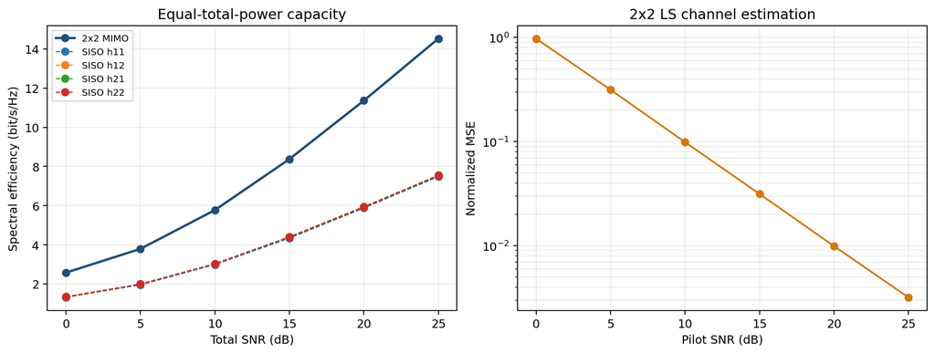

```python
display(Image(filename=str(LAB_ROOT/'expected_figures/task1_mimo_capacity_and_estimation.png'), width=900))
```

**Report:** Include a short interpretation of channel rank and estimation error.

Channel rank determines how many independent spatial streams the MIMO channel can support. Higher-rank channels provide more spatial diversity and higher capacity, which is reflected in Figure 1 by the consistently higher 2×2 MIMO capacity compared to the individual SISO links. Channel estimation error measures how closely the estimated channel matches the true channel. As SNR increases like in Figure 2, the normalized MSE decreases, resulting in more accurate channel estimates and more reliable capacity calculations.

# Lab 6, Task 1B: Receiver Diversity

Compare selection combining, equal-gain combining, and maximum-ratio combining for QPSK over Rayleigh fading.

```python
from pathlib import Path
import sys
import numpy as np
from IPython.display import display, Image

def find_lab_root(start=Path.cwd()):
    for candidate in (start, *start.parents):
        if (candidate / "support" / "lab6_dsp.py").is_file():
            return candidate
    raise FileNotFoundError("Open this notebook from the Lab 6 folder tree")

LAB_ROOT = find_lab_root()
sys.path.insert(0, str(LAB_ROOT / "support"))
import lab6_dsp as lab
import lab6_tools as tools
print("Lab folder:", LAB_ROOT.name)
```

```
Lab folder: Lab6
```

## Diversity simulation

The library supplies channel generation, error counting, and plotting. Set the branch counts and SNR grid.

```python
branch_counts = (1, 2, 3, 4)
snr_db = (0, 21, 4)
results = lab.simulate_diversity(snr_db, branch_counts=tuple(branch_counts), bits_per_point=240000, seed=7602)
for method in ('sc','egc','mrc'):
    print(method.upper(), 'L=4 BER:', results['ber'][method][-1])
```

```
SC L=4 BER: [0.09777917 0.         0.029375  ]
EGC L=4 BER: [0.05272083 0.         0.010425  ]
MRC L=4 BER: [0.040475   0.         0.00686667]
```

## Implement the three combiners

For each symbol, `r` and `h` have shape `(L, N)`. Use the equations in the manual. Normalize each result so the desired QPSK symbol has unit gain.

```python
rng = np.random.default_rng(66)
symbols = lab.qpsk_map(rng.integers(0,2,2000,dtype=np.uint8))
h = (rng.standard_normal((4,symbols.size))+1j*rng.standard_normal((4,symbols.size)))/np.sqrt(2)
r = h*symbols[None,:] + 0.08*(rng.standard_normal(h.shape)+1j*rng.standard_normal(h.shape))/np.sqrt(2)

best = np.argmax(np.abs(h)**2, axis=0)
sc = r[best, np.arange(r.shape[1])] / np.maximum(np.abs(h[best, np.arange(r.shape[1])])**2, 1e-12) * np.conj(h[best, np.arange(r.shape[1])])
egc_weights = np.conj(h) / np.maximum(np.abs(h), 1e-12)
egc = np.sum(egc_weights * r, axis=0) / np.maximum(np.sum(np.abs(h), axis=0), 1e-12)
mrc = np.sum(np.conj(h) * r, axis=0) / np.maximum(np.sum(np.abs(h)**2, axis=0), 1e-12)
print('Bit errors:', {name:int(np.count_nonzero(lab.qpsk_detect(z)!=lab.qpsk_detect(symbols))) for name,z in {'SC':sc,'EGC':egc,'MRC':mrc}.items()})
```

```
Bit errors: {'SC': 0, 'EGC': 0, 'MRC': 0}
```

## Expected plots

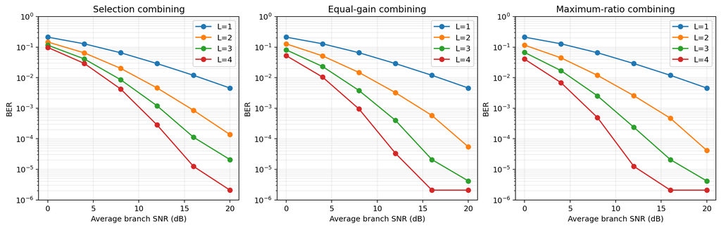

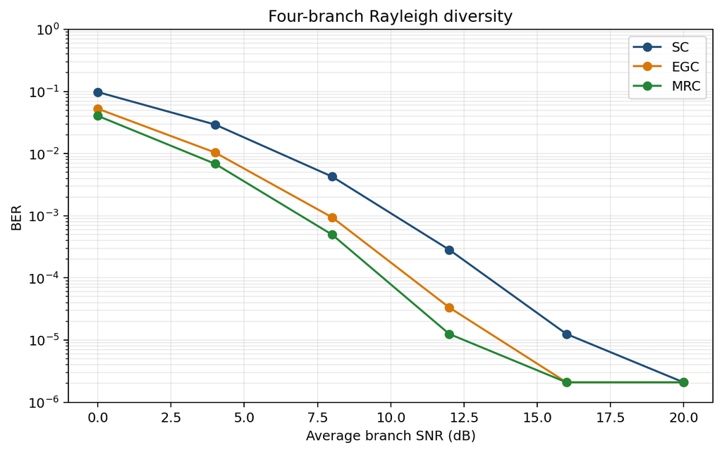

```python
display(Image(filename=str(LAB_ROOT/'expected_figures/task1_diversity_by_method.png'), width=1000))
display(Image(filename=str(LAB_ROOT/'expected_figures/task1_diversity_comparison.png'), width=700))
```

**Report:** Compare BER as a function of SNR and branch count.

As the **branch count** increases from L=1 to L=4, BER decreases significantly for each combining method. Additional branches provide more independent fading paths, increasing diversity gain and reducing the probability that all received signals experience deep fades simultaneously.

**Report:** Compare branch count, BER, channel-knowledge requirements, and computational cost for SC, EGC, and MRC. Explain the performance and complexity tradeoff.

SC, EGC, and MRC all benefit from a higher **branch count**, but they use the available diversity differently. SC only selects the strongest branch and ignores the others, so it achieves the highest **BER** of the three methods. EGC combines all branches after phase alignment, reducing BER by making use of all received signals. MRC further improves performance by weighting each branch according to its channel strength, giving more emphasis to higher-quality signals and achieving the lowest BER.

The **channel-knowledge** requirements increase from SC to EGC to MRC. SC only requires knowledge of the channel magnitude to identify the strongest branch. EGC requires channel phase information so that all branches can be coherently aligned before combining, which requires additional per-branch processing. MRC requires both channel magnitude and phase information because it must determine the proper weighting and phase correction for every branch.

The **computational cost** follows the same trend as **performance**. SC has the lowest complexity because it only compares branch magnitudes and performs detection on a single branch. EGC is more complex because each branch must be phase-corrected and summed. MRC has the highest complexity because each branch must be phase-corrected, weighted by its magnitude, and then combined. The additional channel estimation and processing required by MRC provide the best BER performance, illustrating the tradeoff between complexity and error-rate performance.

# Lab 6, Task 2A: Experimental 2 by 2 MIMO

Generate orthogonal sounding waveforms, collect two synchronized receiver channels, estimate the channel matrix, and compare MIMO and SISO capacity.

```python
from pathlib import Path
import sys
import numpy as np
from IPython.display import display, Image

def find_lab_root(start=Path.cwd()):
    for candidate in (start, *start.parents):
        if (candidate / "support" / "lab6_dsp.py").is_file():
            return candidate
    raise FileNotFoundError("Open this notebook from the Lab 6 folder tree")

LAB_ROOT = find_lab_root()
sys.path.insert(0, str(LAB_ROOT / "support"))
import lab6_dsp as lab
import lab6_tools as tools
print("Lab folder:", LAB_ROOT.name)
```

```
Lab folder: Lab6
```

## Prepare finite dual-channel waveforms

**Report:** Record requested sample rates, carrier frequency, gain, subdevices, antenna selectors, and file sizes.

- **TX Gains:** 40, 45, 50 dB
- **RX Gain:** 60 dB
- **TX Subdevice:** A:0 A:1
- **RX Subdevice:** A:0 A:1
- **TX Antenna:** TX/RX
- **RX Antenna:** TX/RX
- **Carrier Frequency:** 2.45 GB
- **Sample Rate:** 1 MS/s
- **TX File Size:** 24,388,608 bytes
- **RX File Size:** 48,000,000 bytes

```python
tx_gains_db = (40, 45, 50)
rx_gain_db = 60
tx_subdevice = "A:0 A:1"
rx_subdevice = "A:0 A:1"
tx_antenna = "TX/RX"
rx_antenna = "TX/RX"
prep_root = LAB_ROOT/'work'
prepared = tools.prepare_hardware_experiment(
    prep_root/'waveforms', prep_root/'captures', tx_gains_db, rx_gain_db,
    tx_subdevice, rx_subdevice, tx_antenna, rx_antenna
)
print('TX files:', Path(prepared['tx0_path']).name, Path(prepared['tx1_path']).name)
print('Radio configuration:', prepared['summary']['experiment'])
print('Bytes per TX file:', prepared['bytes_per_tx_file'])
```

```
TX files: lab6_tx_ch0_c64.dat lab6_tx_ch1_c64.dat
Radio configuration: {'tx_gains_db': [40, 45, 50], 'rx_gain_db': 60.0, 'noise_samples_per_channel': 250000, 'tx_subdevice': 'A:0 A:1', 'rx_subdevice': 'A:0 A:1', 'tx_antenna': 'TX/RX', 'rx_antenna': 'TX/RX'}
Bytes per TX file: 24388608
```

**Report:** Record actual sample rates, carrier frequency, gain, subdevices, antenna selectors, and file sizes.

- **TX Gains:** 40, 45, 50 dB
- **RX Gain:** 60 dB
- **TX Subdevice:** A:0 A:1
- **RX Subdevice:** A:0 A:1
- **TX Antenna:** TX/RX
- **RX Antenna:** TX/RX
- **Carrier Frequency:** 2.45 GB
- **Sample Rate:** 1 MS/s
- **TX File Size:** 24,388,608 bytes
- **RX File Size:** 48,000,000 bytes

```python
ls -la $LAB_ROOT/work/waveforms
```

```
total 99360
drwxr-xr-x@ 4 marcpham  staff       128 Nov 19 15:46 ./
drwxr-xr-x@ 5 marcpham  staff       160 Nov 19 15:46 ../
-rw-r--r--@ 1 marcpham  staff  24388608 Nov 19 15:54 lab6_tx_ch0_c64.dat
-rw-r--r--@ 1 marcpham  staff  24388608 Nov 19 15:54 lab6_tx_ch1_c64.dat
```

```python
ls -la $LAB_ROOT/work/captures
```

```
total 750024
drwxr-xr-x@ 11 marcpham  staff       352 Nov 19 15:46 ./
drwxr-xr-x@  5 marcpham  staff       160 Nov 19 15:46 ../
-rw-r--r--@  1 marcpham  staff      1130 Nov 19 15:54 lab6_measurement_summary.json
-rw-r--r--@  1 marcpham  staff  48000000 Nov 19 15:46 lab6_noise_ch0_c64.dat
-rw-r--r--@  1 marcpham  staff  48000000 Nov 19 15:46 lab6_noise_ch1_c64.dat
-rw-r--r--@  1 marcpham  staff  48000000 Nov 19 15:46 lab6_rx_tx40_ch0_c64.dat
-rw-r--r--@  1 marcpham  staff  48000000 Nov 19 15:46 lab6_rx_tx40_ch1_c64.dat
-rw-r--r--@  1 marcpham  staff  48000000 Nov 19 15:46 lab6_rx_tx45_ch0_c64.dat
-rw-r--r--@  1 marcpham  staff  48000000 Nov 19 15:46 lab6_rx_tx45_ch1_c64.dat
-rw-r--r--@  1 marcpham  staff  48000000 Nov 19 15:46 lab6_rx_tx50_ch0_c64.dat
-rw-r--r--@  1 marcpham  staff  48000000 Nov 19 15:46 lab6_rx_tx50_ch1_c64.dat
```

### Receiver Flowgraph

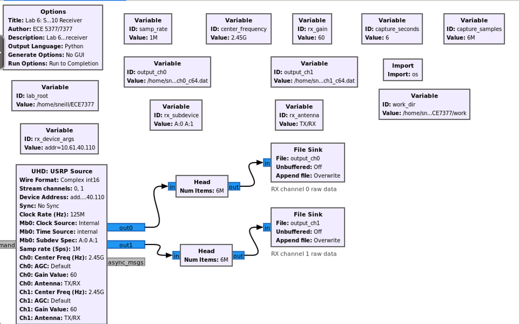

### Monitor Flowgraph

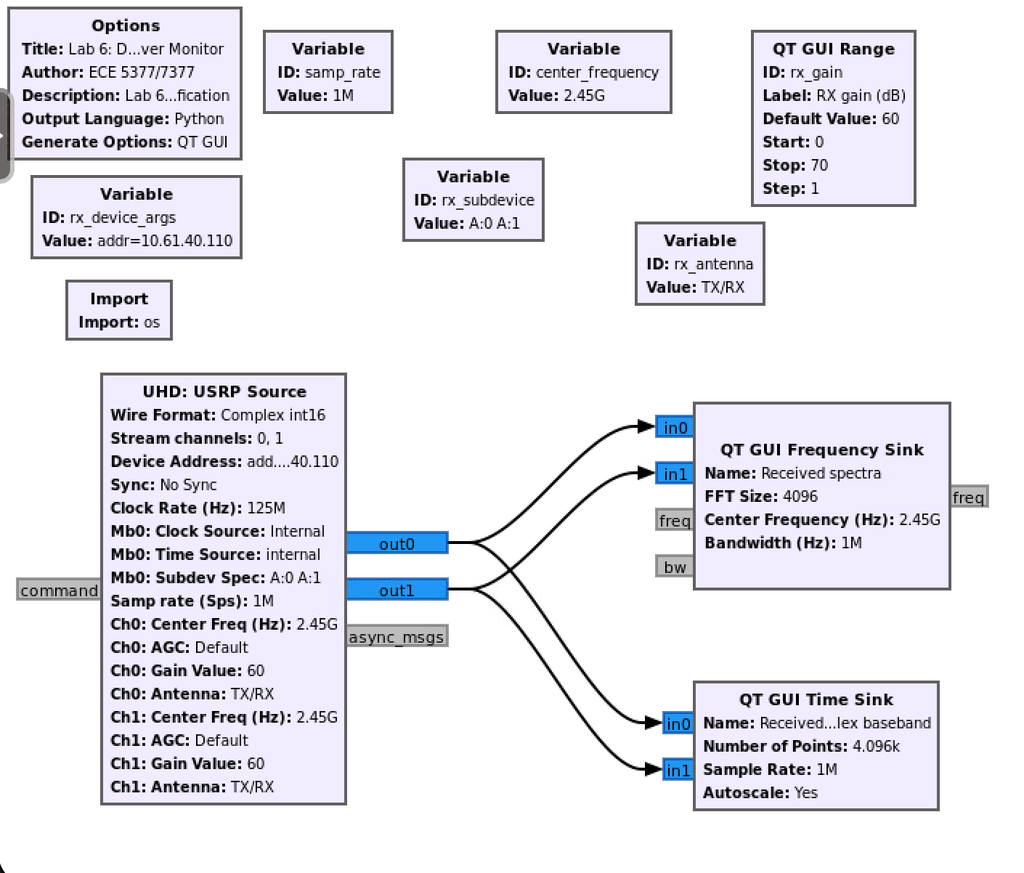

### Transmitter Flowgraph

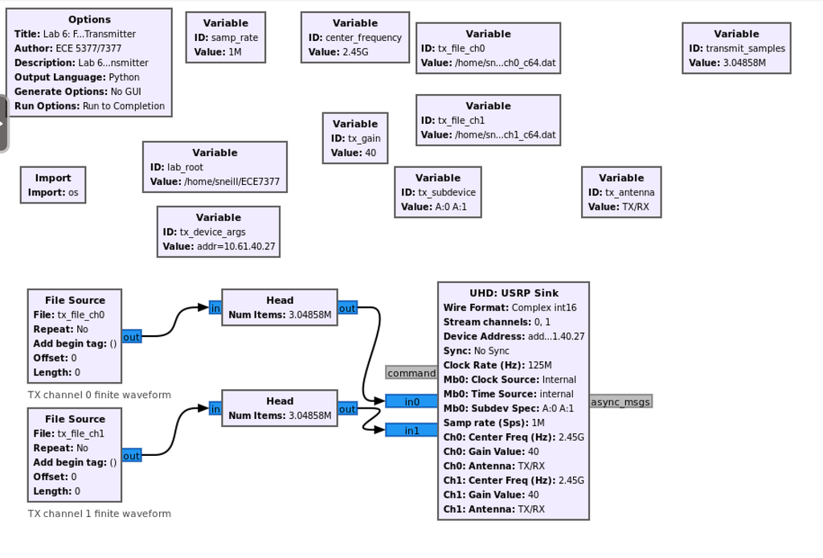

## GNU Radio capture

Use the provided transmitter, receiver monitor, and finite receiver flowgraphs as directed in the manual. Run the receiver before the transmitter. Save one noise-only record and one dual-channel record at each TX gain.

```python
from pathlib import Path
import sys

LAB_ROOT = Path("/home/sneill/ECE7377")
sys.path.insert(0, str(LAB_ROOT / "support"))

import lab6_tools as tools

output_dir = LAB_ROOT / "expected_figures"

results = tools.generate_simulation(output_dir)

print("Figures generated successfully!")
for file in sorted(output_dir.glob("*.png")):
    print(file.name)
```

```
Figures generated successfully!
task1_diversity_by_method.png
task1_diversity_comparison.png
task1_mimo_capacity_and_estimation.png
task2_waveform_schedule.png
```

**Report:** Include the verification spectrum.

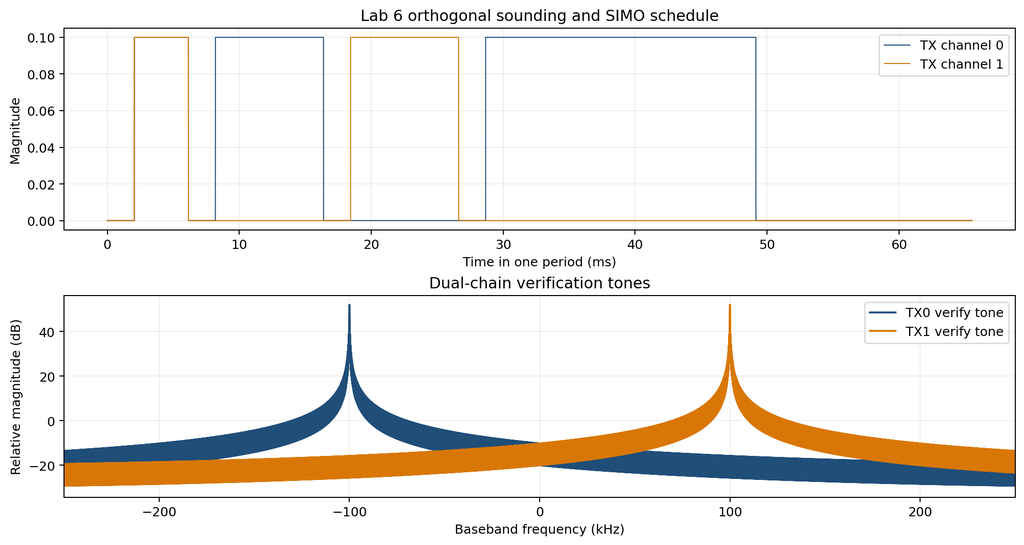

```python
display(Image(filename=str(LAB_ROOT/'expected_figures/task2_waveform_schedule.png'), width=900))
```

## Analyze the captures

The library performs acquisition, CFO correction, plotting, and repeated-frame aggregation. You are responsible for checking the matrix calculation and interpreting the result.

```python
capture_dir = LAB_ROOT/'work/captures'
figure_dir = LAB_ROOT/'work/figures'
hardware = tools.analyze_hardware(capture_dir, figure_dir)
for gain, values in hardware['gains'].items():
    print(gain, 'frames', values['analyzed_frames'], 'capacity', round(values['mimo_capacity_mean_bps_hz'],3), 'condition', round(values['condition_number_mean'],3))
```

```
tx40 frames 15 capacity 35.06 condition 9.118
tx45 frames 15 capacity 40.666 condition 9.105
tx50 frames 15 capacity 43.978 condition 9.105
```

**Report:** Include one channel matrix per gain, MIMO and SISO capacity versus gain, and condition number.

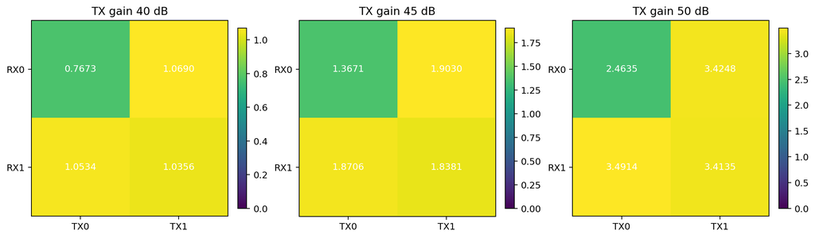

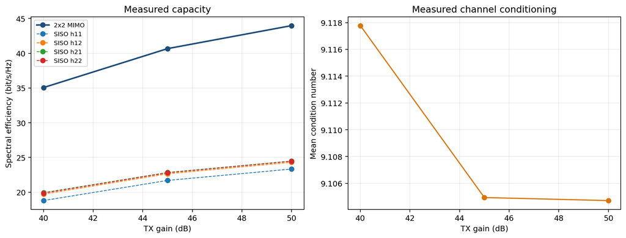

```python
display(Image(filename=str(figure_dir/'task2_hardware_channel_matrices.png'), width=1000))
display(Image(filename=str(figure_dir/'task2_hardware_capacity.png'), width=900))
```

## Check one capacity calculation

```python
middle = hardware['gains'][f'tx{tx_gains_db[1]}']
h_real = np.array(middle['mimo_channel_reference']['real'])
h_imag = np.array(middle['mimo_channel_reference']['imag'])
h_hat = h_real + 1j*h_imag
noise = np.mean(hardware['noise_variance'])

rho = 2 * (0.1 ** 2) / noise
capacity_check = np.log2(
    np.linalg.det(
        np.eye(h_hat.shape[0]) +
        (rho / h_hat.shape[1]) * (h_hat @ h_hat.conj().T)
    )
).real
print('Representative H:\n',np.round(h_hat,4))
print('Capacity check:',capacity_check)
print('Stored reference-frame capacity:',middle['mimo_capacity_reference_bps_hz'])
```

```
Representative H:
 [[1.3026-0.4149j 1.8078-0.5943j]
 [1.8543-0.2464j 1.8197+0.2599j]]
Capacity check: 40.67147705360864
Stored reference-frame capacity: 40.67147705360865
```

**Report:** Explain why orthogonal pilots are required.

Orthogonal pilots are used so that each column of the channel matrix H can be estimated separately. In this experiment, the waveform transmits a TX0-only pilot followed by a TX1-only pilot at the same baseband frequency. Because the pilots are time-orthogonal, the receiver can isolate the channel contribution from each transmit antenna and estimate all four channel coefficients of the 2×2 MIMO channel matrix. If both transmitters sent the same-frequency pilot simultaneously, their contributions would overlap, making the channel estimates more difficult and less accurate.

# Lab 6, Task 2B: Experimental Receiver Diversity

Use the SIMO field in the dual-channel capture to compare SC, EGC, and MRC with measured channel coefficients.

```python
from pathlib import Path
import sys
import numpy as np
from IPython.display import display, Image

def find_lab_root(start=Path.cwd()):
    for candidate in (start, *start.parents):
        if (candidate / "support" / "lab6_dsp.py").is_file():
            return candidate
    raise FileNotFoundError("Open this notebook from the Lab 6 folder tree")

LAB_ROOT = find_lab_root()
sys.path.insert(0, str(LAB_ROOT / "support"))
import lab6_dsp as lab
import lab6_tools as tools
print("Lab folder:", LAB_ROOT.name)
```

```
Lab folder: Lab6
```

## Load one acquired frame

```python
capture_dir = LAB_ROOT/'work/captures'
summary = __import__('json').loads((capture_dir/'lab6_measurement_summary.json').read_text())
tx_gains_db = tuple(int(value) for value in summary['experiment']['tx_gains_db'])
gain = tx_gains_db[1]
waveform = lab.build_waveform()
rx0 = lab.load_complex64(capture_dir/f'lab6_rx_tx{gain}_ch0_c64.dat', lab.CAPTURE_SAMPLES)
rx1 = lab.load_complex64(capture_dir/f'lab6_rx_tx{gain}_ch1_c64.dat', lab.CAPTURE_SAMPLES)
noise0 = lab.load_complex64(capture_dir/'lab6_noise_ch0_c64.dat')[:250000]
noise1 = lab.load_complex64(capture_dir/'lab6_noise_ch1_c64.dat')[:250000]
if noise0.size < 250000 or noise1.size < 250000:
    raise ValueError('Each noise record must contain at least 250000 samples.')
capture = lab.analyze_hardware_capture(rx0,rx1,noise0,noise1,waveform)
frame = capture['analyzed_frames'][0]
r = frame['payload_symbols_rx']
h = frame['simo_channel']
print('SIMO channel:',h)
```

```
SIMO channel: [0.30484301+0.9496475j  0.17128772+1.35659233j]
```

## Combine the two measured branches

`r` contains two rows of received QPSK symbols. `h` contains one complex flat-fading estimate per receive branch.

```python
h_matrix = np.repeat(h[:,None],r.shape[1],axis=1)

best = np.argmax(np.abs(h)**2)
sc = (r[best] / h[best]) / lab.DIGITAL_PEAK
egc_weights = np.exp(-1j * np.angle(h))
egc = (
    np.sum(egc_weights[:, None] * r, axis=0)
    / np.sum(np.abs(h))
) / lab.DIGITAL_PEAK
mrc = (
    np.sum(np.conj(h)[:, None] * r, axis=0)
    / np.sum(np.abs(h)**2)
) / lab.DIGITAL_PEAK
outputs={'sc':sc,'egc':egc,'mrc':mrc}
for name,z in outputs.items():
    errors=np.count_nonzero(lab.qpsk_detect(z)!=waveform.payload_bits)
    print(name.upper(),'errors',errors,'BER',errors/waveform.payload_bits.size,'EVM',lab.rms_evm(z,waveform.payload_symbols))
```

```
SC errors 0 BER 0.0 EVM 0.09636212878027776
EGC errors 0 BER 0.0 EVM 0.09559051409074473
MRC errors 0 BER 0.0 EVM 0.09571617194848195
```

## Plotting supplied

**Report:** Include both branch constellations, all three combined constellations, BER or error counts, EVM, and a received-quality and received power comparison across TX gain.

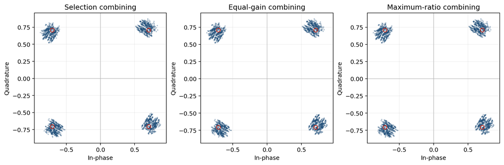

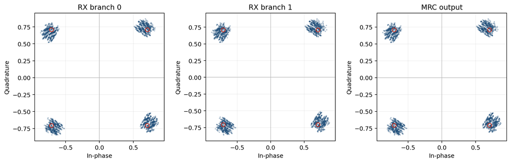

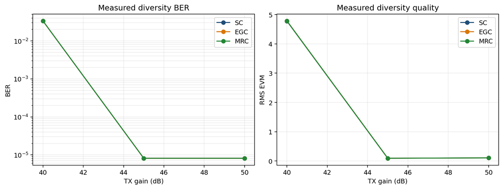

```python
out = LAB_ROOT/'work/figures/task2_student_diversity_outputs.png'
tools.plot_diversity_outputs(outputs,out)
display(Image(filename=str(out),width=1000))
figure_dir = LAB_ROOT / 'work/figures'
hardware_results = tools.analyze_hardware(capture_dir, figure_dir)
display(Image(
    filename=str(figure_dir / 'task2_hardware_diversity_constellations.png'),
    width=1000
))
display(Image(
    filename=str(figure_dir / 'task2_hardware_diversity_metrics.png'),
    width=1000
))
```

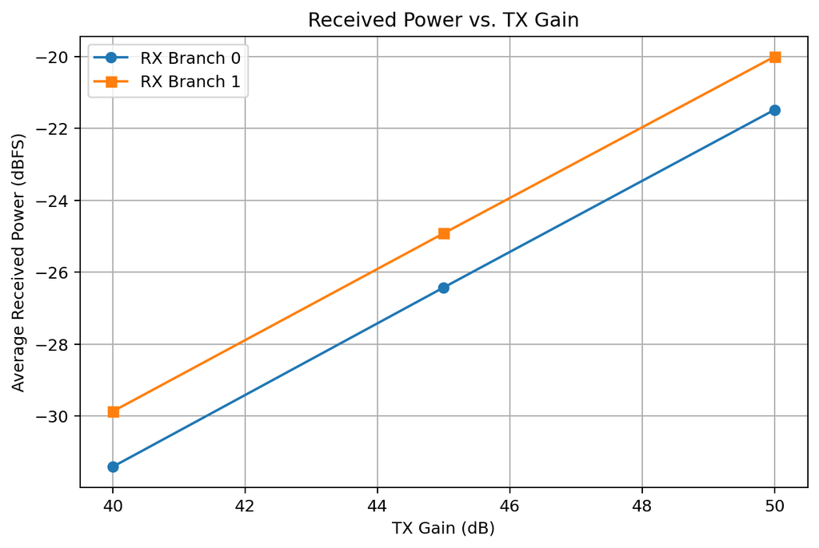

```python
import matplotlib.pyplot as plt
rx0_power_db = []
rx1_power_db = []
for gain in tx_gains_db:
    rx0 = lab.load_complex64(
        capture_dir / f'lab6_rx_tx{gain}_ch0_c64.dat',
        lab.CAPTURE_SAMPLES
    )
    rx1 = lab.load_complex64(
        capture_dir / f'lab6_rx_tx{gain}_ch1_c64.dat',
        lab.CAPTURE_SAMPLES
    )
    p0 = np.mean(np.abs(rx0)**2)
    p1 = np.mean(np.abs(rx1)**2)
    rx0_power_db.append(10 * np.log10(p0))
    rx1_power_db.append(10 * np.log10(p1))
plt.figure(figsize=(8, 5))
plt.plot(tx_gains_db, rx0_power_db, 'o-', label='RX Branch 0')
plt.plot(tx_gains_db, rx1_power_db, 's-', label='RX Branch 1')
plt.xlabel('TX Gain (dB)')
plt.ylabel('Average Received Power (dBFS)')
plt.title('Received Power vs. TX Gain')
plt.grid(True)
plt.legend()
plt.savefig(
    LAB_ROOT / 'work/figures/task2_received_power_vs_tx_gain.png',
    dpi=180,
    bbox_inches='tight'
)
from IPython.display import display, Image
display(Image(
    filename=str(LAB_ROOT / 'work/figures/task2_received_power_vs_tx_gain.png'),
    width=900
))
```

**Report:** Compare measured trends with the Task 1B simulation.

The measured diversity results followed the same overall trend as the Task 1B simulation in that performance improved as signal conditions became stronger. In the simulation, increasing SNR reduced BER, and MRC provided the best performance, followed by EGC and then SC. Similarly, in the experimental measurements, increasing TX gain from 40 dB to 45 dB significantly reduced BER and RMS EVM, with little additional improvement between 45 dB and 50 dB. However, unlike the simulation, the measured BER and EVM curves for SC, EGC, and MRC were nearly identical. This is likely because the two receive branches experienced very similar channel conditions, resulting in limited diversity gain. As a result, all three combining methods produced similar constellation quality and error performance. Overall, the measurements confirmed the expected improvement in signal quality with increasing TX gain, but the performance differences between SC, EGC, and MRC were much smaller than predicted by the idealized Rayleigh-fading simulation in Task 1B.

**Report:** Explain when diversity is preferable to spatial multiplexing.

Diversity is preferred when the goal is reliable communication rather than maximum throughput. By combining multiple received copies of the same signal, diversity reduces fading and improves BER and EVM. Spatial multiplexing increases data rate by transmitting multiple streams simultaneously but requires stronger channel conditions and good separation between spatial channels.